# Images

Images are really just 2D arrays (or lists) where each element corresponds to a brightness value. Let's show that with a plot:

```
[[ 1  2  3]
 [ 4  5  6]
 [ 7  8  9]
 [10 11 12]]
(4, 3)
```

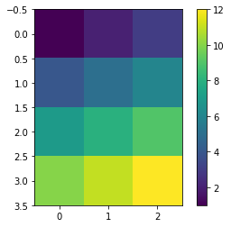

```python
import numpy as np
import matplotlib.pyplot as pl

grid = np.array([[1,2,3], [4,5,6], [7,8,9], [10,11,12]])
print(grid)
print(grid.shape)

pl.imshow(grid)
pl.colorbar()
```

Notice that the first row of the array was plotted at the top of the image.

This may be counterintuitive if when you think of row #0 you think of y = 0, which, in a normal $x$-$y$ coordinate system is on the bottom.

It is standard in programming to have the first row at the top, but this can be changed if desired using the `origin` keyword argument:

```
[[ 1  2  3]
 [ 4  5  6]
 [ 7  8  9]
 [10 11 12]]
```

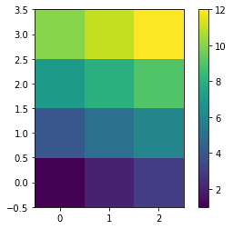

```python
print(grid) # for reference
pl.imshow(grid, origin="lower")
pl.colorbar()
```

Interpolation makes an image look smoother. Here we turn interpolation. There are [many kinds](https://matplotlib.org/stable/gallery/images_contours_and_fields/interpolation_methods.html) of interpolation.

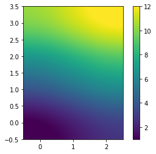

```python
pl.imshow(grid, origin="lower", interpolation="spline16")
pl.colorbar()
```

```python
grid  # for reference
```

```
array([[ 1,  2,  3],
       [ 4,  5,  6],
       [ 7,  8,  9],
       [10, 11, 12]])
```

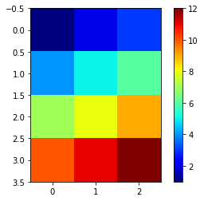

```python
pl.imshow(grid, interpolation="none", cmap="jet")  # With a different colormap
pl.colorbar()
```

## Finding particular elements in a 2D array

```python
print(grid)  # for reference
```

```
[[ 1  2  3]
 [ 4  5  6]
 [ 7  8  9]
 [10 11 12]]
```

Find indices of all elements with values > 5:

```python
print(np.argwhere(grid > 5))
```

```
[[1 2]
 [2 0]
 [2 1]
 [2 2]
 [3 0]
 [3 1]
 [3 2]]
```

## Array computing

As we saw in the previous lesson, we can do math on entire arrays at once:

```python
print(grid)
print()
print(grid * 2)
```

```
[[ 1  2  3]
 [ 4  5  6]
 [ 7  8  9]
 [10 11 12]]

[[ 2  4  6]
 [ 8 10 12]
 [14 16 18]
 [20 22 24]]
```

```python
print(grid)
print()
print(grid + 5)
```

```
[[ 1  2  3]
 [ 4  5  6]
 [ 7  8  9]
 [10 11 12]]

[[ 6  7  8]
 [ 9 10 11]
 [12 13 14]
 [15 16 17]]
```

We can also add, subtract, multiply, and divide 2 arrays **so long as they have the same shape.**

```python
newGrid = grid + 10

print(grid)
print()
print(newGrid)
print()
print(grid + newGrid)
```

```
[[ 1  2  3]
 [ 4  5  6]
 [ 7  8  9]
 [10 11 12]]

[[11 12 13]
 [14 15 16]
 [17 18 19]
 [20 21 22]]

[[12 14 16]
 [18 20 22]
 [24 26 28]
 [30 32 34]]
```

## Using colorbar limits in plots

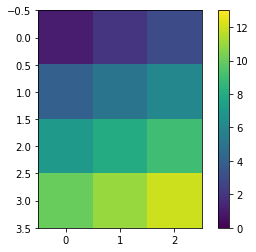

```python
pl.imshow(grid, interpolation="none")
pl.colorbar()
pl.clim(0, 13)  # colorbar limits, analogous to xlim, ylim
```

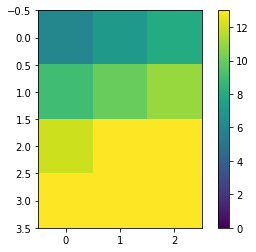

```python
pl.imshow(grid + 5)  # Brightening the array by a value of 5 everywhere
pl.colorbar()
pl.clim(0, 13)  # Notice how this affects the output with the brighter array
```

## Handling image files

We can also load image files and use them as arrays:

```python
from PIL import Image

im = Image.open("data/HelixNebula.jpg")
print(im)
```

```
<PIL.JpegImagePlugin.JpegImageFile image mode=RGB size=2560x1600 at 0x7F89E8C4AF10>
```

So this is an image file. Can we plot it directly?

[figure not shown]

```python
pl.figure(figsize=(10, 7))
pl.imshow(im)
```

Can we turn it into an array to do math on it?

```python
imageArray = np.array(im)
print(imageArray)
```

```
[[[17 12 19]
  [14  9 16]
  [22 17 24]
  ...
  [30  8 11]
  [46 24 27]
  [48 26 29]]

 [[16 11 18]
  [11  6 13]
  [18 13 20]
  ...
  [34 12 15]
  [36 14 17]
  [31  9 12]]

 [[21 16 23]
  [16 11 18]
  [21 16 23]
  ...
  [41 21 23]
  [34 14 16]
  [30 10 12]]

 ...

 [[41 32 35]
  [40 31 34]
  [44 35 40]
  ...
  [43 22 27]
  [43 22 27]
  [31 10 15]]

 [[41 35 37]
  [37 31 33]
  [33 27 31]
  ...
  [44 21 27]
  [51 28 36]
  [36 13 21]]

 [[27 23 24]
  [26 22 23]
  [27 21 25]
  ...
  [41 18 24]
  [55 32 40]
  [48 25 33]]]
```

```python
print(np.shape(imageArray))
```

```
(1600, 2560, 3)
```

So this is a 3D array? Let's slice along the first two dimensions to crop the image:

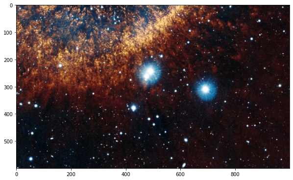

```python
pl.figure(figsize=(10, 7))
pl.imshow(imageArray[1000:1600, 1000:2000, :]) # What will this show?
pl.show()
```

What is this third dimension? It's as if there are three different 2D arrays stacked on top of each other. Let's plot each of these three 2D images out to investigate what they are:

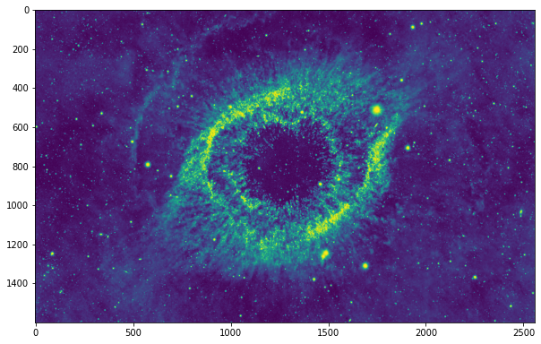

```python
pl.figure(figsize=(10, 7))
pl.imshow(imageArray[:, :, 0]) # Outer ring of nebula bright, stars dim
pl.show()
```

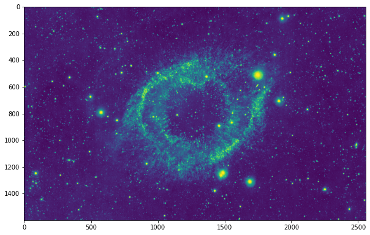

```python
pl.figure(figsize=(10, 7))
pl.imshow(imageArray[:, :, 1])
pl.show()
```

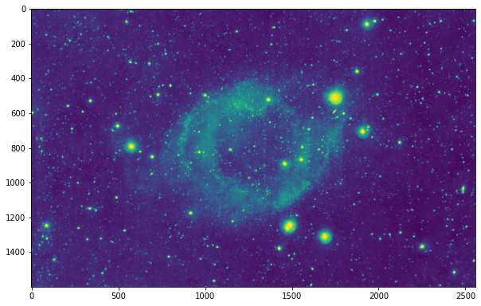

```python
pl.figure(figsize=(10, 7))
pl.imshow(imageArray[:, :, 2])
pl.show()
```

Compare each of these with the original image. Notice that the blue stars are bright in the last of the three images, and the red portion of the image is brighter in the first of the three. Each of these three images are the values of red, green, and blue (R, G, B) in the original image.

So the dimensions of the 3D array are height (in pixels), width (in pixels), and color (R, G, B)!

Copyright © Brian Davis. All Rights Reserved.